# Презентация по лабораторной работе №8

Операционные системы

Куокконен Дарина Андреевна, НКАбд-03-23

Российский университет дружбы народов, Москва, Россия

24 марта 2024

## Цель работы

Цель данной лабораторной работы - ознакомление с инструментами поиска файлов и фильтрации текстовых данных. Приобретение практических навыков: по управлению процессами (и заданиями), по проверке использования диска и обслуживанию файловых систем.

## Задание

1. Осуществить вход в систему, используя соответствующее имя пользователя.
2. Записать в файл file.txt названия файлов, содержащихся в каталоге /etc
3. Выведите имена всех файлов из file.txt, имеющих расширение .conf
4. Запустите в фоновом режиме процесс, который будет записывать в файл ~/logfile файлы, имена которых начинаются с log.
5. Удалить лишние файлы
6. Выполнить команды df и du

## Выполнение лабораторной работы

Вхожу в систему,используя соответствующее имя пользователя. С помощью перенапраления “>” добавляю в файл file.txt название файлов из /etc. (рис. 1).

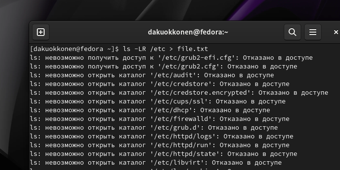

Запись в файл

## Выполнение лабораторной работы

С помощью команды head проверяю первые 10 строк файла (рис. 2).

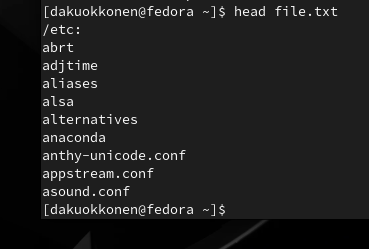

Проверка файла

## Выполнение лабораторной работы

Вывожу на экран имена всех файлов,содержащих расщирение .conf, с помощию команды grep (рис. 4).

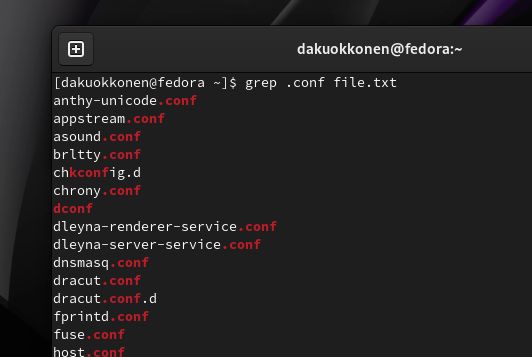

Поиск файлов

## Выполнение лабораторной работы

Записываю найденные файлы в новый файл (рис. 5).

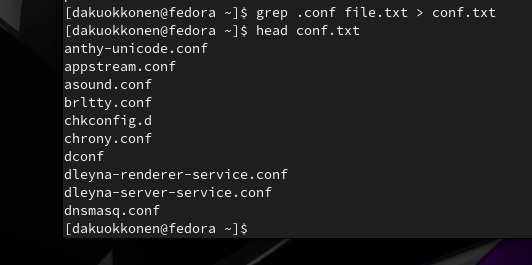

Запись в файл

## Выполнение лабораторной работы

Нахожу в домашнем каталоге все файлы,которые начинаются на “c” (рис. 6).

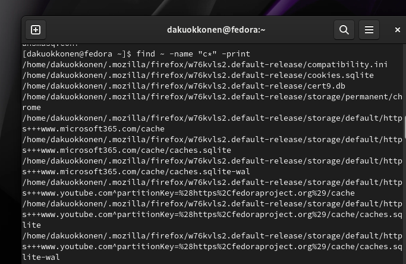

Поиск имен файлов

## Выполнение лабораторной работы

Еще один способ найти элементы с первым символов. Однако этот способ не работает для поиска файлов из подкаталогов (рис. 7).

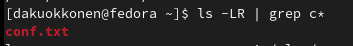

Поиск имен файлов

## Выполнение лабораторной работы

С помощью опции find, вывожу на экран имена файлов из каталог /etc,начинающихся с символа h (рис. 8).

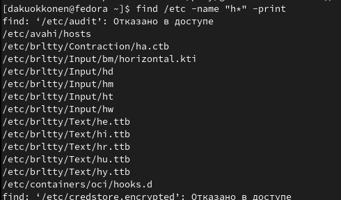

Поиск файлов

## Выполнение лабораторной работы

Проверяю,что файл создан и удаляю его (рис. 10).

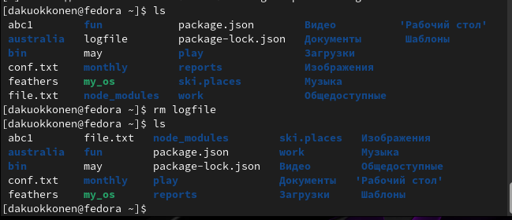

Удаление файла

## Выполнение лабораторной работы

Запускаю в фоновом режиме редактор mousepad (рис. 11).

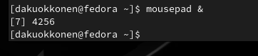

Запуск процесса в фоновом режиме

## Выполнение лабораторной работы

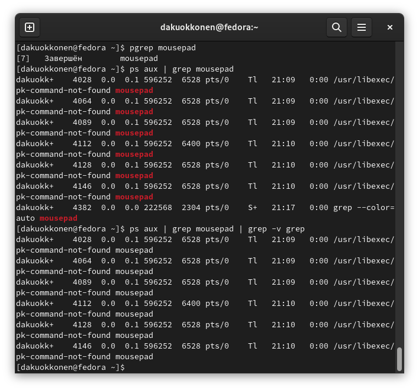

Определение идентификатора разными способами

## Выполнение лабораторной работы

Удаляю процесс (рис. 13).

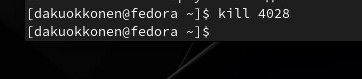

Удаление процесса

## Выполнение лабораторной работы

Изучаю справку команды df и выполняю её,использовав утилиту -iv, которая позволяет увидеть информацию об инодах и сделать вывод читаемым.игнорирую сообщение системы о нем,так мы узнаем,сколько у нашей системы места (рис. 14).

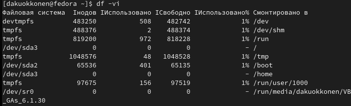

Команда df

## Выполнение лабораторной работы

Изучаю справку команды du и выполняю её,использовав утилиту -а,которая позволяет увидеть,сколько памяти занимают все файлы (рис. 15).

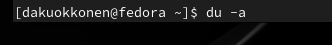

Команда du

## Выполнение лабораторной работы

Выполняю команду du (рис. 16).

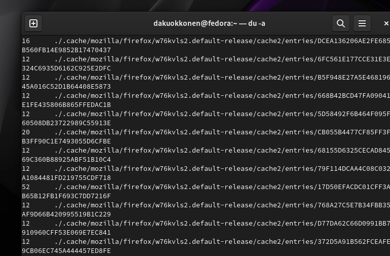

Выполнение команды

# Выводы

Я ознакомилась с инструментами поиска файлов и фильтрации текстовых данных,приобрела практические навыки: по управлению процессами (и заданиями), попроверке использования диска и обслуживанию файловых систем.